# Kaggle Survey

Zehui(Barry) Zhang, Lu Xu

In this project, we will start from general aspect to specific topics. Considering gender as the main orientation, and starting from that, we will go and find out different feathers in different genders, and do the estimates.

# 2 Basic Analysis

### 2.0 Data Procesing

Load the data and fill all blanks with NA. Remove the first row which is the questions of the survey. Then make two subsets based on Man and Woman.

```r
library(dplyr)
setwd("~/Downloads")
dat = read.csv("~/Downloads/kaggle_survey_2020_responses.csv",na.strings=c("","NA"))
dat = dat[-c(1),]

male = subset(dat,dat$Q2 == "Man")
female = subset(dat,dat$Q2 == "Woman")
nrow(male)
```

```
## [1] 15789
```

```r
nrow(female)
```

```
## [1] 3878
```

### 2.1 General Glance

Generally count the number of participants in different genders, and associate it with age, country, and level of education. And show and analyze graphically.

Gender only

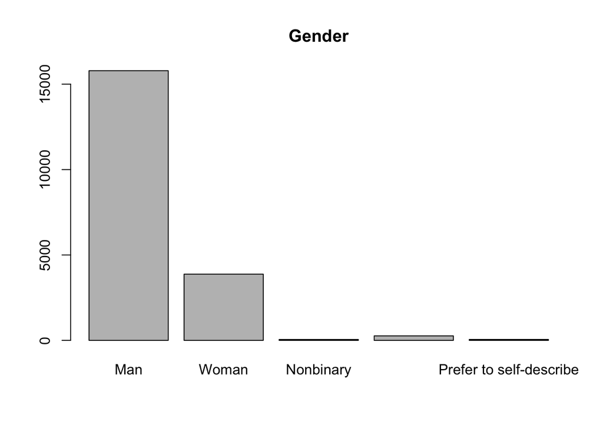

```r
gender = c("Man", "Woman", "Nonbinary", "Prefer not to say", "Prefer to self-describe")
count = rep(NULL,5)
for (j in 1:5){
  count[j] = length(which(dat$Q2 == gender[j]))
}
Gender = data.frame(Gender = gender, num = count)
barplot(Gender$num, main = "Gender", names.arg = Gender$Gender)
```

Gender and Age

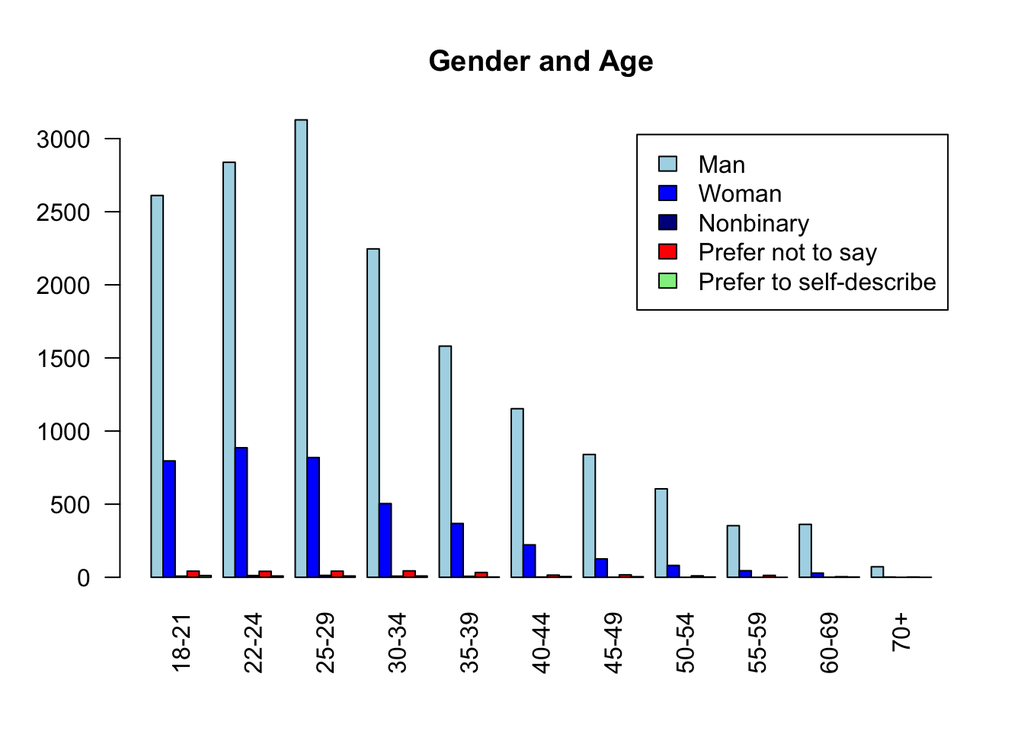

```r
age = sort(unique(dat$Q1), decreasing = FALSE)
num = rep(NULL,5*11)
for (i in 1:11){
  count = rep(NULL,5)
  for (j in 1:5){
    count[j] = length(which(dat$Q1 == age[i] & dat$Q2 == gender[j]))
  }
  num = c(num,count)
}

age2 = matrix(num,ncol = 11, byrow = FALSE)
colnames(age2) = age
rownames(age2) = gender

barplot(age2, main = "Gender and Age",col = c("lightblue", 'blue','darkblue','red','lightgreen'), legend = gender,beside = TRUE,las = 2)
```

Gender and Country

```r
country = sort(unique(dat$Q3), decreasing = FALSE)
count = rep(NULL,55)
for (j in 1:55){
  count[j] = length(which(dat$Q3 == country[j]))
}
count
```

```
##  [1]  134  231  143   59   60  694  301   85  474  177  179  330  404   52  111
## [16] 5851  290  162   54   97  267  638  153  133  227  133   62  151  476 1388
## [31]  283   95   99  148  122   76   61  582   76  149  141  190  336   72   78
## [46]   68  267  132   99  344  170   59  489 2237  147
```

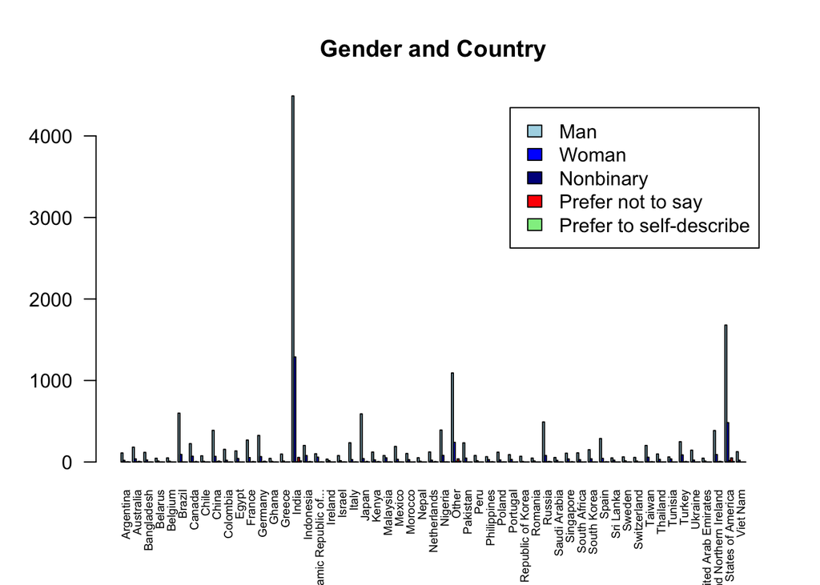

```r
num = rep(NULL,5*55)
for (i in 1:55){
  counts = rep(NULL,5)
  for (j in 1:5){
    counts[j] = length(which(dat$Q3 == country[i] & dat$Q2 == gender[j]))
  }
  num = c(num,counts)
}

country2 = matrix(num,ncol = 55, byrow = FALSE)
colnames(country2) = country
rownames(country2) = gender

barplot(country2, main = "Gender and Country",col = c("lightblue", 'blue','darkblue','red','lightgreen'),cex.names=0.6,legend = gender,beside = TRUE,las=2)
```

Gender of Top 10 Countries

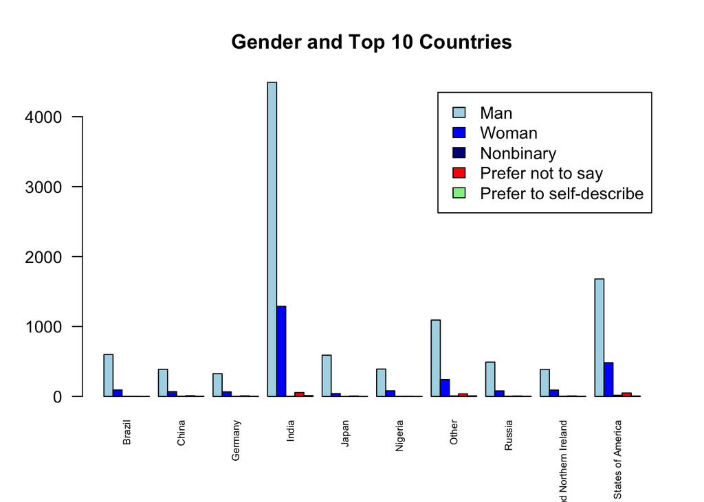

```r
index = which(count > 350)
index = c(index)
top = country[index]

num2 = rep(NULL,5*10)
for (i in 1:10){
  count = rep(NULL,5)
  for (j in 1:5){
    count[j] = length(which(dat$Q3 == top[i] & dat$Q2 == gender[j]))
  }
  num2 = c(num2,count)
}

country3 = matrix(num2,ncol = 10, byrow = FALSE)
colnames(country3) = top
rownames(country3) = gender

barplot(country3, main = "Gender and Top 10 Countries",col = c("lightblue", 'blue','darkblue','red','lightgreen'),cex.names=0.6,legend = gender,beside = TRUE,las=2)
```

Gender of Level of Formal Education

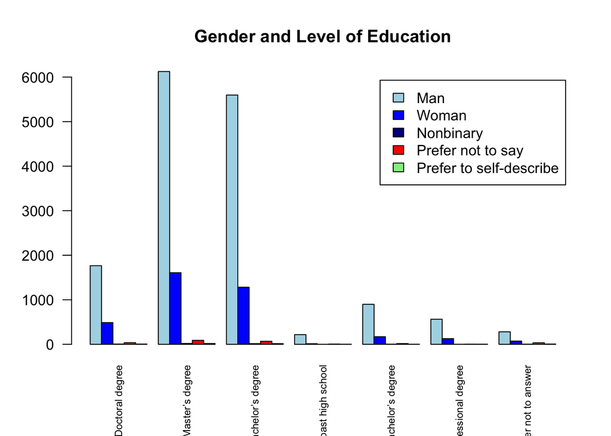

```r
edu = unique(dat$Q4)

num3 = rep(NULL,5*7)
for (i in 1:7){
  count = rep(NULL,5)
  for (j in 1:5){
    count[j] = length(which(dat$Q4 == edu[i] & dat$Q2 == gender[j]))
  }
  num3 = c(num3,count)
}

edu2 = matrix(num3, ncol = 7, byrow = FALSE)
colnames(edu2) = edu[1:7]
rownames(edu2) = gender

barplot(edu2, main = "Gender and Level of Education",col = c("lightblue", 'blue','darkblue','red','lightgreen'),cex.names=0.7,legend = gender,beside = TRUE,las=2)
```

### 2.2 Within the Gender

After the analysis in the prior part, we found that Man and Woman almost dominate the proportion in all comparisons. Thus in this part, we narrow our direction to Man and Woman only. By pie chart, it is easy and straightforward to check the proportion within each gender.

Man and Woman with Age

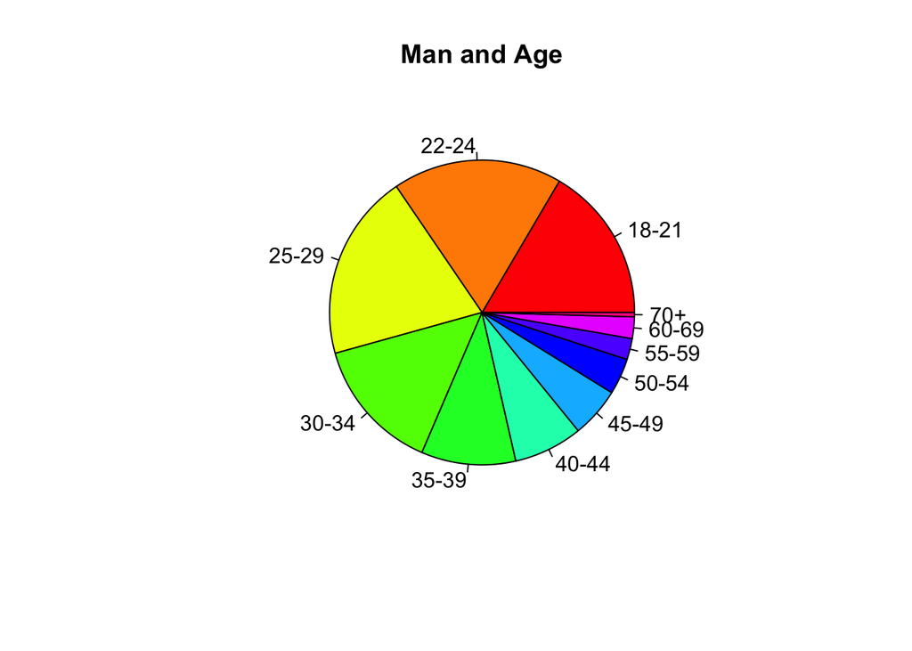

```r
# Man
age = sort(unique(dat$Q1), decreasing = FALSE)
mc = rep(NULL,11)
for (i in 1:11){
  mc[i] = length(which(male$Q1 == age[i]))
}
ma = matrix(mc, ncol = 11, byrow = FALSE)
colnames(ma) = age
rownames(ma) = "Man"
pie(ma,labels = age,col = rainbow(length(age)), main = "Man and Age")
```

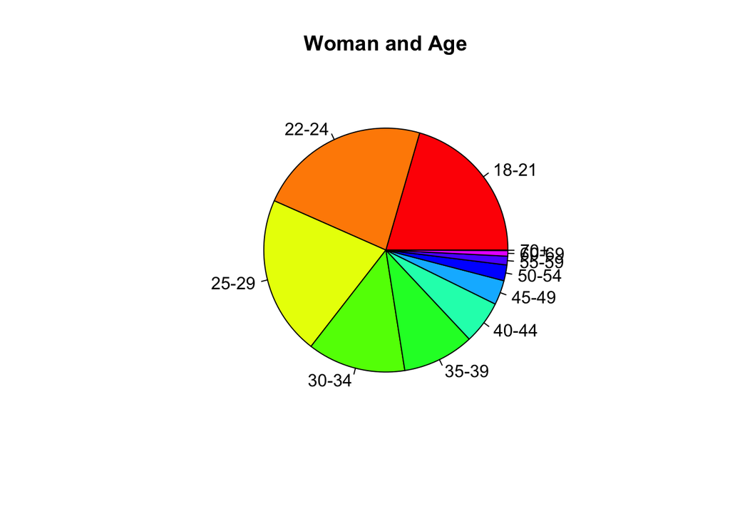

```r
# Woman
fc = rep(NULL,11)
for (i in 1:11){
  fc[i] = length(which(female$Q1 == age[i]))
}
fa = matrix(fc, ncol = 11, byrow = FALSE)
colnames(fa) = age
rownames(fa) = "Woman"
pie(fa, labels = age,col = rainbow(length(age)),main = "Woman and Age")
```

Man and Woman with countries

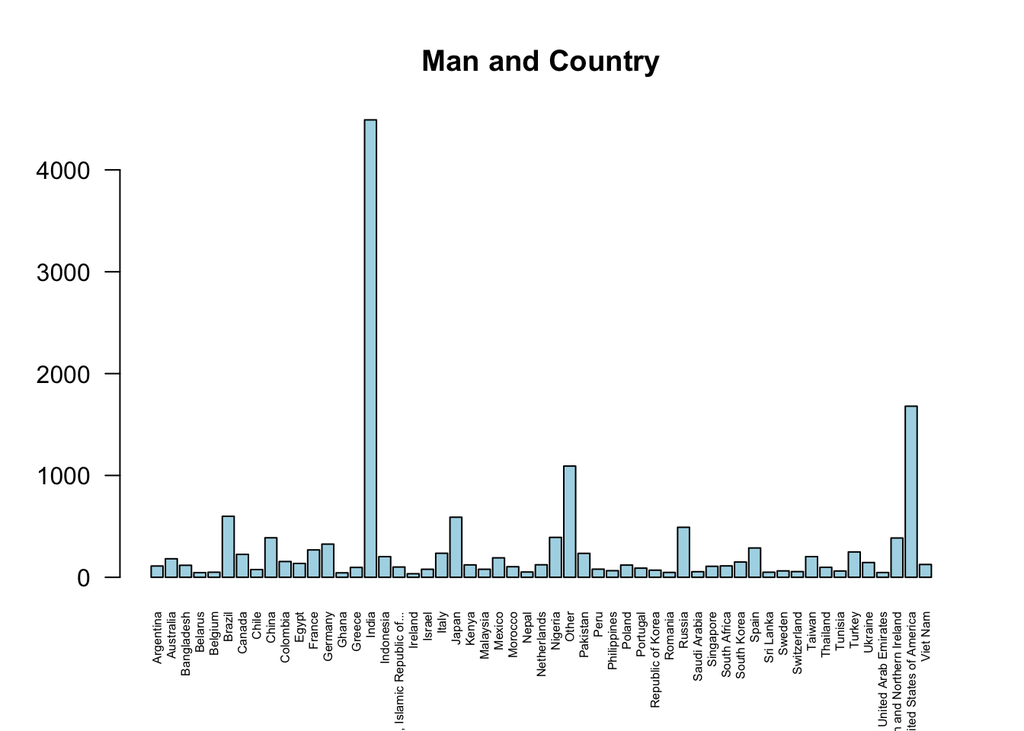

```r
mc2 = rep(NULL,55)
for (i in 1:55){
  mc2[i] = length(which(male$Q3 == country[i]))
}
ma2 = matrix(mc2, ncol = 55, byrow = FALSE)
colnames(ma2) = country
rownames(ma2) = "Man"
barplot(ma2, main = "Man and Country",cex.names=0.5,col = "lightblue",las = 2)
```

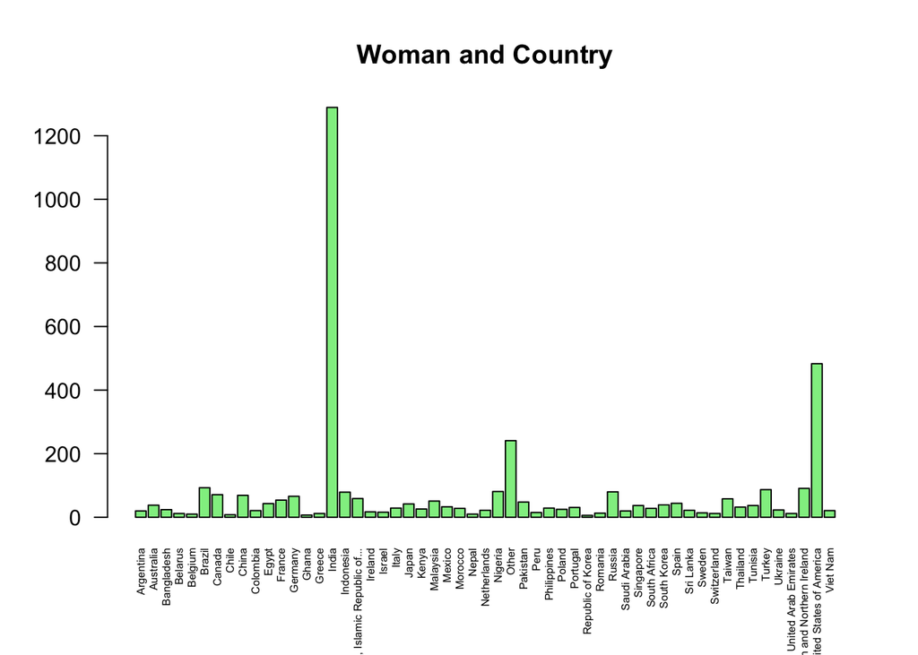

```r
# Woman
fc2 = rep(NULL,55)
for (i in 1:55){
  fc2[i] = length(which(female$Q3 == country[i]))
}
fa2 = matrix(fc2, ncol = 55, byrow = FALSE)
colnames(fa2) = country
rownames(fa2) = "Woman"
barplot(fa2, main = "Woman and Country",cex.names=0.5,col = "lightgreen",las = 2)
```

Man and Woman with Top 10 Countries

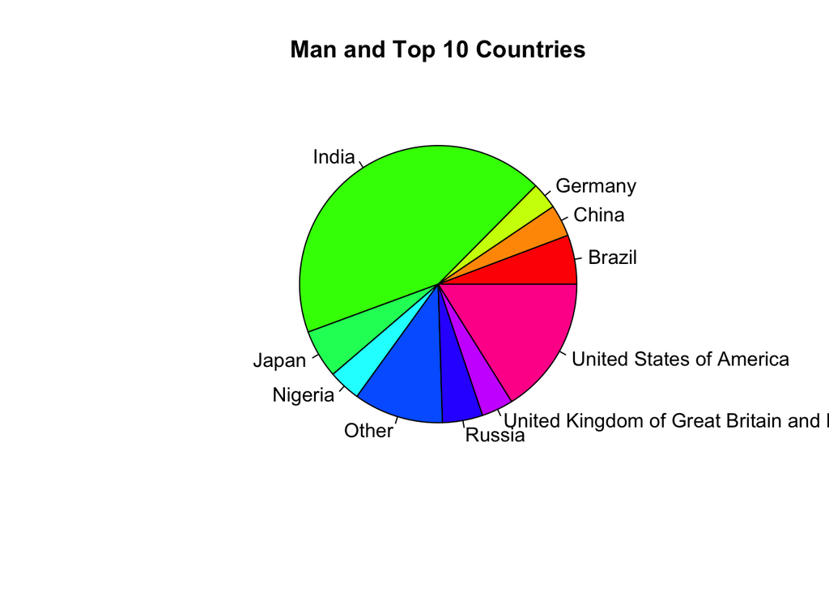

```r
mc3 = rep(NULL,10)
for (i in 1:10){
  mc3[i] = length(which(male$Q3 == top[i]))
}
ma3 = matrix(mc3, ncol = 10, byrow = FALSE)
colnames(ma3) = top
rownames(ma3) = "Man"
pie(ma3,labels = top,col = rainbow(length(top)), main = "Man and Top 10 Countries")
```

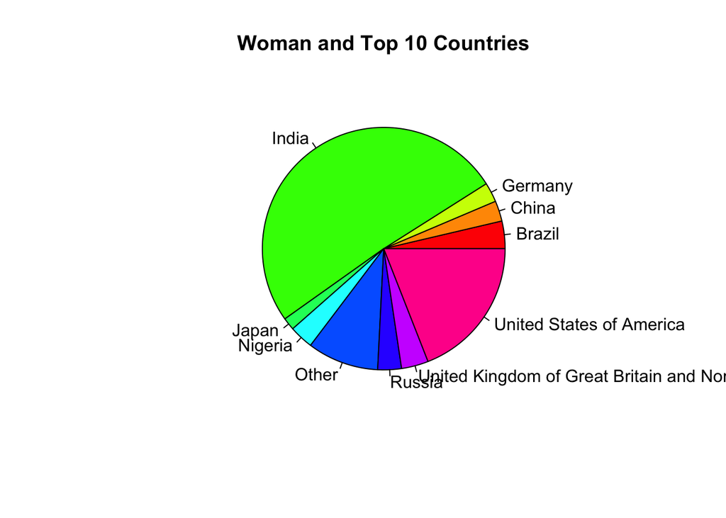

```r
# Woman
fc3 = rep(NULL,10)
for (i in 1:10){
  fc3[i] = length(which(female$Q3 == top[i]))
}
fa3 = matrix(fc3, ncol = 10, byrow = FALSE)
colnames(fa3) = top
rownames(fa3) = "Woman"
pie(fa3, labels = top,col = rainbow(length(top)),main = "Woman and Top 10 Countries")
```

Compare the level of formal education

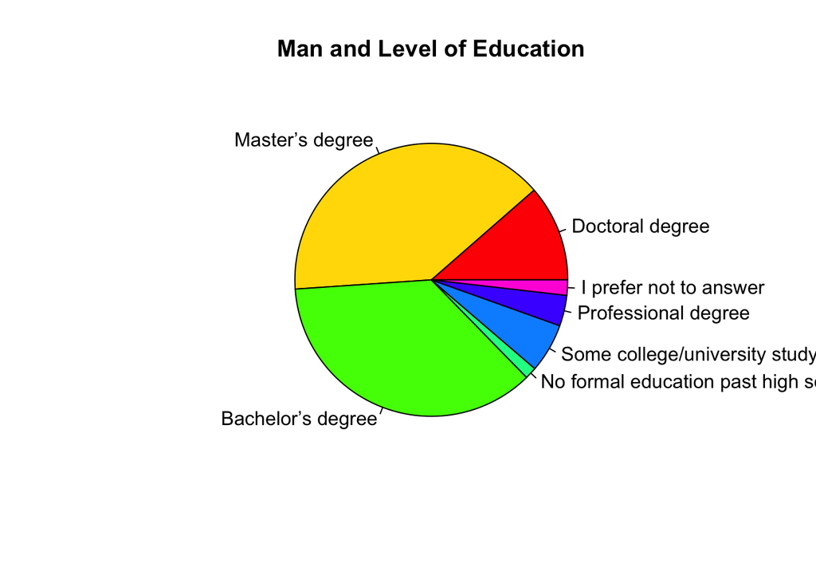

```r
# Man
mc4 = rep(NULL,7)
for (i in 1:7){
  mc4[i] = length(which(male$Q4 == edu[i]))
}
ma4 = matrix(mc4, ncol = 7, byrow = FALSE)
colnames(ma4) = edu[1:7]
rownames(ma4) = "Man"
pie(ma4, labels = edu[1:7],col = rainbow(7),main = "Man and Level of Education")
```

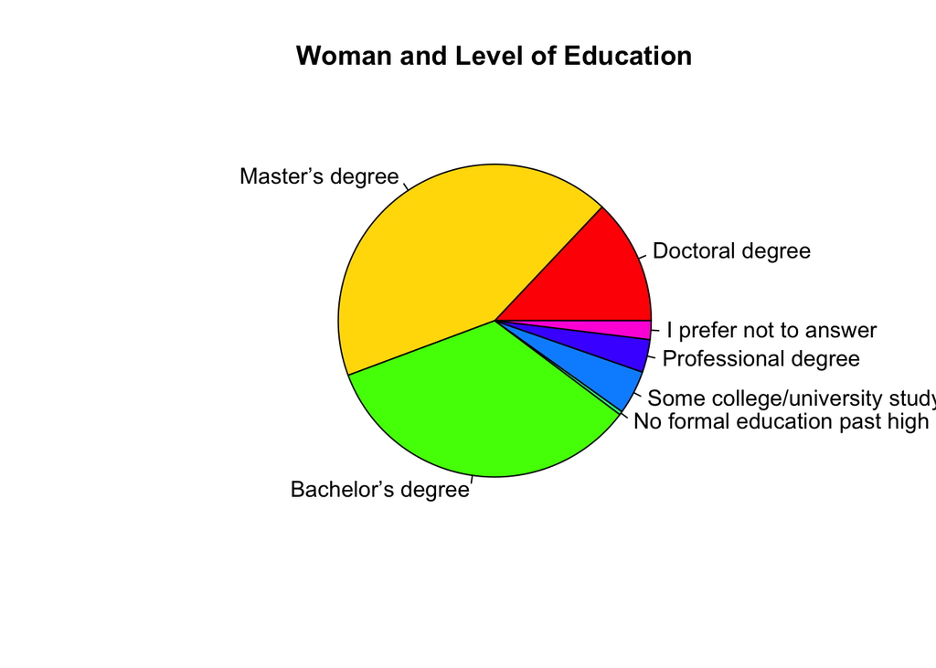

```r
# Woman
fc4 = rep(NULL,7)
for (i in 1:7){
  fc4[i] = length(which(female$Q4 == edu[i]))
}
fa4 = matrix(fc4, ncol = 7, byrow = FALSE)
colnames(fa4) = edu[1:7]
rownames(fa4) = "Woman"
pie(fa4, labels = edu[1:7],col = rainbow(7),main = "Woman and Level of Education")
```

### 2.3 Working Experiences

In this part, we will figure out the connection between Roles and Coding experiences, and make both point and interval estimate for the fraction of students with few coding experiences. Then check if gender affects this.

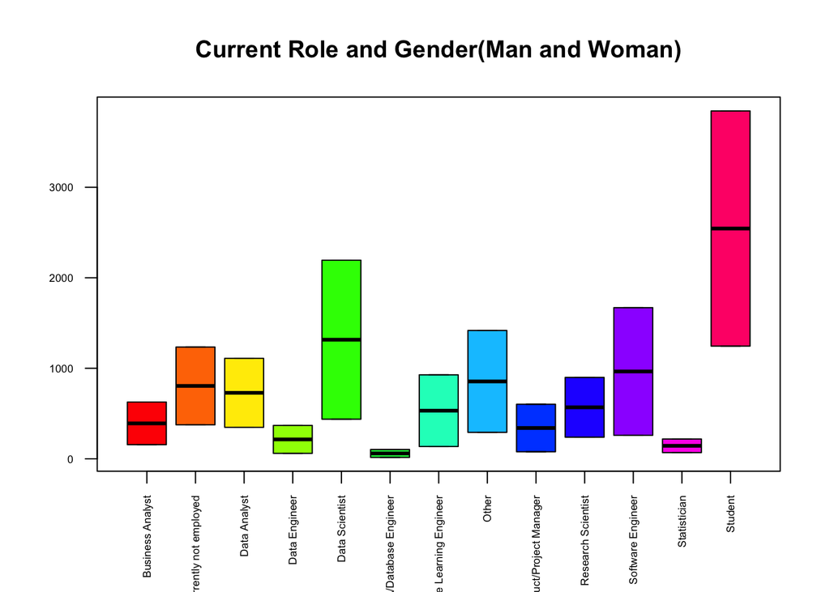

```r
# graph for the current role
Role = sort(unique(dat$Q5))
newgender = c("Man", "Woman")
num4 = rep(NULL,2*13)
for (i in 1:13){
  count = rep(NULL,5)
  for (j in 1:2){
    count[j] = length(which(dat$Q5 == Role[i] & dat$Q2 == newgender[j]))
  }
  num4 = c(num4,count)
}

Role2 = matrix(num4, ncol = 13, byrow = FALSE)
colnames(Role2) = Role
rownames(Role2) = newgender

par(cex.axis=0.55)
boxplot(Role2, main = "Current Role and Gender(Man and Woman)",col = rainbow(13),las = 2)
```

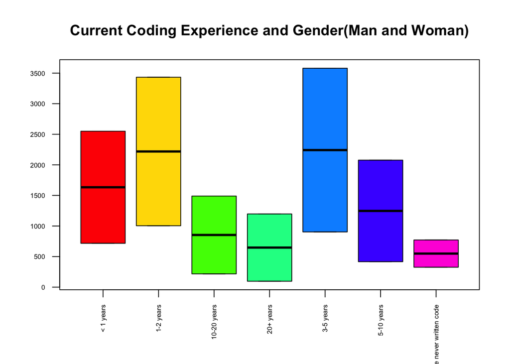

```r
# Graph for coding experience
ct = sort(unique(dat$Q6))
num5 = rep(NULL,2*7)
for (i in 1:7){
  count = rep(NULL,5)
  for (j in 1:2){
    count[j] = length(which(dat$Q6 == ct[i] & dat$Q2 == newgender[j]))
  }
  num5 = c(num5,count)
}

ct2 = matrix(num5, ncol = 7, byrow = FALSE)
colnames(ct2) = ct
rownames(ct2) = newgender

par(cex.axis=0.55)
boxplot(ct2, main = "Current Coding Experience and Gender(Man and Woman)",col = rainbow(7),las = 2)
```

Point estimate and interval estimate

```r
# number of students with few coding experience
n = length(which(dat$Q5 == "Student" & dat$Q6 == "< 1 years")) + length(which(dat$Q5 == "Student" & dat$Q6 == "1-2 years"))

# Estimator, SE and 95% Confidence Interval
# Among all students
xbar1 = n / length(which(dat$Q5 == "Student"))
SE1 = ((xbar1 * (1 - xbar1))^(0.5)) / (length(which(dat$Q5 == "Student")))^(0.5)
CI1 = c(xbar1 - 2 * SE1, xbar1 + 2 * SE1)
xbar1
```

```
## [1] 0.593889
```

```r
SE1
```

```
## [1] 0.006829482
```

```r
CI1
```

```
## [1] 0.580230 0.607548
```

```r
# Among all participants
xbar2 = n / nrow(dat)
SE2 = ((xbar2 * (1 - xbar2))^(0.5)) / (nrow(dat))^(0.5)
CI2 = c(xbar2 - 2 * SE2, xbar2 + 2 * SE2)
xbar2
```

```
## [1] 0.1532741
```

```r
SE2
```

```
## [1] 0.002545073
```

```r
CI2
```

```
## [1] 0.1481840 0.1583643
```

fraction with gender

```r
# Man in students
t1 = length(which(dat$Q2 == "Man" & dat$Q5 == "Student" & dat$Q6 == "< 1 years"))
t2 = length(which(dat$Q2 == "Man" & dat$Q5 == "Student" & dat$Q6 == "1-2 years"))
n2 = t1+t2

xbar3 = n2 / length(which(dat$Q2 == "Man" & dat$Q5 == "Student"))
SE3 = ((xbar3 * (1 - xbar3))^(0.5)) / (length(which(dat$Q2 == "Man" & dat$Q5 == "Student")))^(0.5)
CI3 = c(xbar3 - 2 * SE3, xbar3 + 2 * SE3)
# Man in all participants
xbar5 = n2 / nrow(dat)
SE5 = ((xbar5 * (1 - xbar5))^(0.5)) / (nrow(dat))^(0.5)
CI5 = c(xbar5 - 2 * SE5, xbar5 + 2 * SE5)
xbar3
```

```
## [1] 0.5958886
```

```r
CI3
```

```
## [1] 0.5800569 0.6117203
```

```r
xbar5
```

```
## [1] 0.1142943
```

```r
CI5
```

```
## [1] 0.1097987 0.1187898
```

```r
# Woman in students
t3 = length(which(dat$Q2 == "Woman" & dat$Q5 == "Student" & dat$Q6 == "< 1 years"))
t4 = length(which(dat$Q2 == "Woman" & dat$Q5 == "Student" & dat$Q6 == "1-2 years"))
n3= t3+t4

xbar4 = n3 / length(which(dat$Q2 == "Woman" & dat$Q5 == "Student"))
SE4 = ((xbar4 * (1 - xbar4))^(0.5)) / (length(which(dat$Q2 == "Woman" & dat$Q5 == "Student")))^(0.5)
CI4 = c(xbar4 - 2 * SE4, xbar4 + 2 * SE4)
# Woman in all participants
xbar6 = n3 / nrow(dat)
SE6 = ((xbar6 * (1 - xbar6))^(0.5)) / (nrow(dat))^(0.5)
CI6 = c(xbar6 - 2 * SE6, xbar6 + 2 * SE6)
xbar4
```

```
## [1] 0.5919679
```

```r
CI4
```

```
## [1] 0.5641104 0.6198253
```

```r
xbar6
```

```
## [1] 0.03678379
```

```r
CI6
```

```
## [1] 0.03412420 0.03944338
```

### 2.4 Languages

Coding languages are the most essential parts of data work. So in this part, we will make both point and interval estimate for the average number of languages used in regular basis for new student coders.

```r
# Counts the number of languages used
students = subset(dat, dat$Q5 == "Student")[1:20]
students$na_count <- apply(students, 1, function(x) sum(is.na(x)))
num_lan = c(13 - students$na_count)
students$num_lan = num_lan

# Estimate, SE, CI and PI( average number of known languages)
x = students$num_lan
n = nrow(students)

Xbar = mean(x)
SEx = sd(x) / sqrt(n)
SDx = sd(x)
CIx = c(Xbar - 2 * SEx, Xbar + 2 * SEx)
PIx = c(Xbar - 2 * SDx, Xbar + 2 * SDx)
Xbar
```

```
## [1] 2.508606
```

```r
CIx
```

```
## [1] 2.463063 2.554148
```

```r
PIx
```

```
## [1] -0.7663349  5.7835462
```

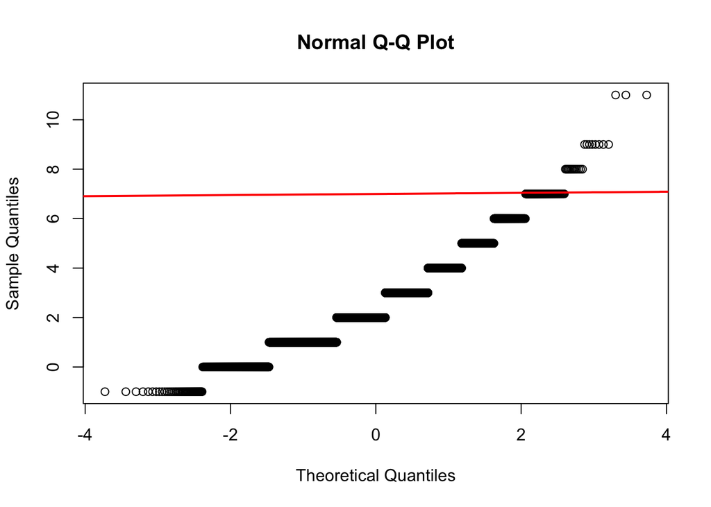

```r
# Graph
qqnorm(x)
abline(x, SEx, col = "red", lwd = 2)
```

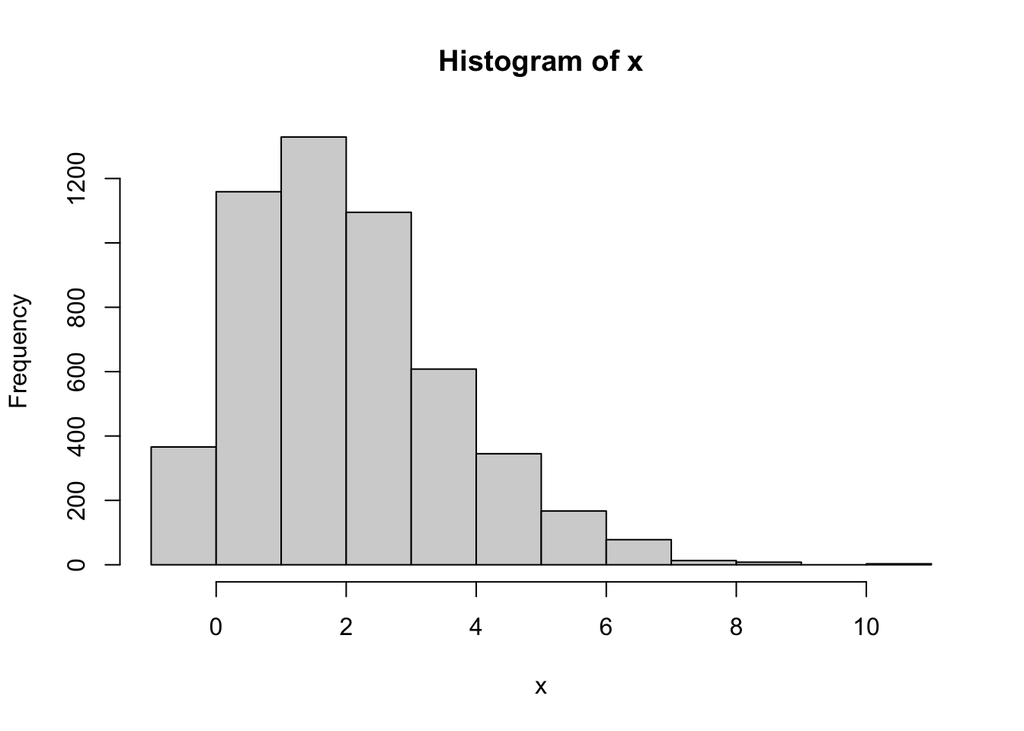

```r
hist(x)
```

# 3 Advanced Analysis

After the previous analysis we did above, there is a question: does the longer coding experience coders have, the more languages they usually use on a regular basis? Do the different coding experiences imply different numbers of languages they use? In this part, we will figure it out.

```r
ano = students[c(7,22)]
ano = ano %>% arrange(desc(Q6))
index = which(ano$Q6 == "I have never written code")
ano = ano[-index,]
result = aov(ano$num_lan ~ ano$Q6)
summary(result)
```

```
##               Df Sum Sq Mean Sq F value Pr(>F)
## ano$Q6         5   1008  201.55   94.42 <2e-16 ***
## Residuals   4828  10305    2.13
## ---
## Signif. codes:  0 '***' 0.001 '**' 0.01 '*' 0.05 '.' 0.1 ' ' 1
## 44 observations deleted due to missingness
```

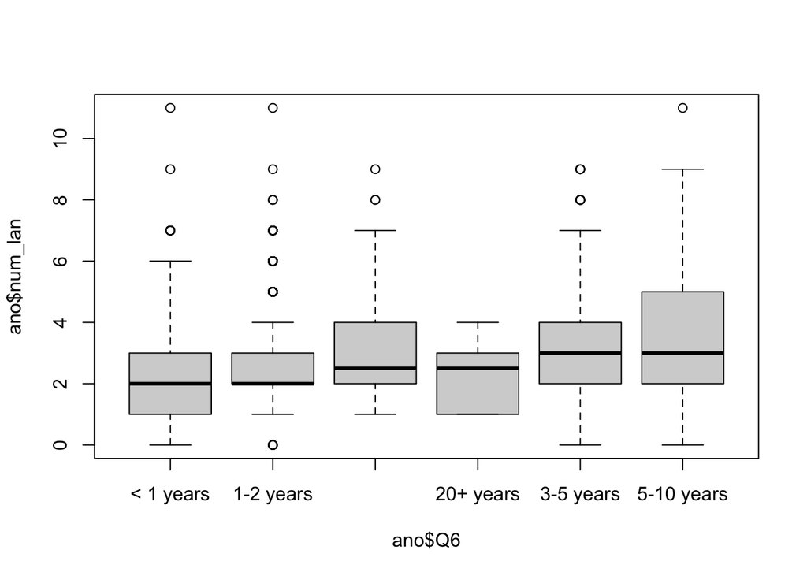

```r
boxplot(ano$num_lan ~ ano$Q6)
```